# HW3

Load data, ggplot2:

```r
data(tips, package="reshape2")
library("ggplot2")
```

## 1.

```r
numParty <- nrow(tips)
numParty
```

```
## [1] 244
```

It appears that there were 244 parties served by the waiter.

## 2.

```r
str(tips)
```

```
## 'data.frame':    244 obs. of  7 variables:
##  $ total_bill: num  17 10.3 21 23.7 24.6 ...
##  $ tip       : num  1.01 1.66 3.5 3.31 3.61 4.71 2 3.12 1.96 3.23 ...
##  $ sex       : Factor w/ 2 levels "Female","Male": 1 2 2 2 1 2 2 2 2 2 ...
##  $ smoker    : Factor w/ 2 levels "No","Yes": 1 1 1 1 1 1 1 1 1 1 ...
##  $ day       : Factor w/ 4 levels "Fri","Sat","Sun",..: 3 3 3 3 3 3 3 3 3 3 ...
##  $ time      : Factor w/ 2 levels "Dinner","Lunch": 1 1 1 1 1 1 1 1 1 1 ...
##  $ size      : int  2 3 3 2 4 4 2 4 2 2 ...
```

You can see here that there are numbers, strings, and ints in this data frame.

## 3.

```r
tips$day <- factor(tips$day, levels = c("Mon", "Tues", "Wed", "Thur", "Fri", "Sat", "Sun"))
day <- tips[order(tips$day), "day"]
day
```

```
##   [1] Thur Thur Thur Thur Thur Thur Thur Thur Thur Thur Thur Thur Thur Thur
##  [15] Thur Thur Thur Thur Thur Thur Thur Thur Thur Thur Thur Thur Thur Thur
##  [29] Thur Thur Thur Thur Thur Thur Thur Thur Thur Thur Thur Thur Thur Thur
##  [43] Thur Thur Thur Thur Thur Thur Thur Thur Thur Thur Thur Thur Thur Thur
##  [57] Thur Thur Thur Thur Thur Thur Fri  Fri  Fri  Fri  Fri  Fri  Fri  Fri
##  [71] Fri  Fri  Fri  Fri  Fri  Fri  Fri  Fri  Fri  Fri  Fri  Sat  Sat  Sat
##  [85] Sat  Sat  Sat  Sat  Sat  Sat  Sat  Sat  Sat  Sat  Sat  Sat  Sat  Sat
##  [99] Sat  Sat  Sat  Sat  Sat  Sat  Sat  Sat  Sat  Sat  Sat  Sat  Sat  Sat
## [113] Sat  Sat  Sat  Sat  Sat  Sat  Sat  Sat  Sat  Sat  Sat  Sat  Sat  Sat
## [127] Sat  Sat  Sat  Sat  Sat  Sat  Sat  Sat  Sat  Sat  Sat  Sat  Sat  Sat
## [141] Sat  Sat  Sat  Sat  Sat  Sat  Sat  Sat  Sat  Sat  Sat  Sat  Sat  Sat
## [155] Sat  Sat  Sat  Sat  Sat  Sat  Sat  Sat  Sat  Sat  Sat  Sat  Sat  Sat
## [169] Sun  Sun  Sun  Sun  Sun  Sun  Sun  Sun  Sun  Sun  Sun  Sun  Sun  Sun
## [183] Sun  Sun  Sun  Sun  Sun  Sun  Sun  Sun  Sun  Sun  Sun  Sun  Sun  Sun
## [197] Sun  Sun  Sun  Sun  Sun  Sun  Sun  Sun  Sun  Sun  Sun  Sun  Sun  Sun
## [211] Sun  Sun  Sun  Sun  Sun  Sun  Sun  Sun  Sun  Sun  Sun  Sun  Sun  Sun
## [225] Sun  Sun  Sun  Sun  Sun  Sun  Sun  Sun  Sun  Sun  Sun  Sun  Sun  Sun
## [239] Sun  Sun  Sun  Sun  Sun  Sun
## Levels: Mon Tues Wed Thur Fri Sat Sun
```

## 4.

```r
female <- tips[(tips$sex == 'Female'),]
female5 <- female[(female$size >= 5),]
female5
```

```
##     total_bill  tip    sex smoker  day   time size
## 126      29.80 4.20 Female     No Thur  Lunch    6
## 144      27.05 5.00 Female     No Thur  Lunch    6
## 156      29.85 5.14 Female     No  Sun Dinner    5
```

## 5.

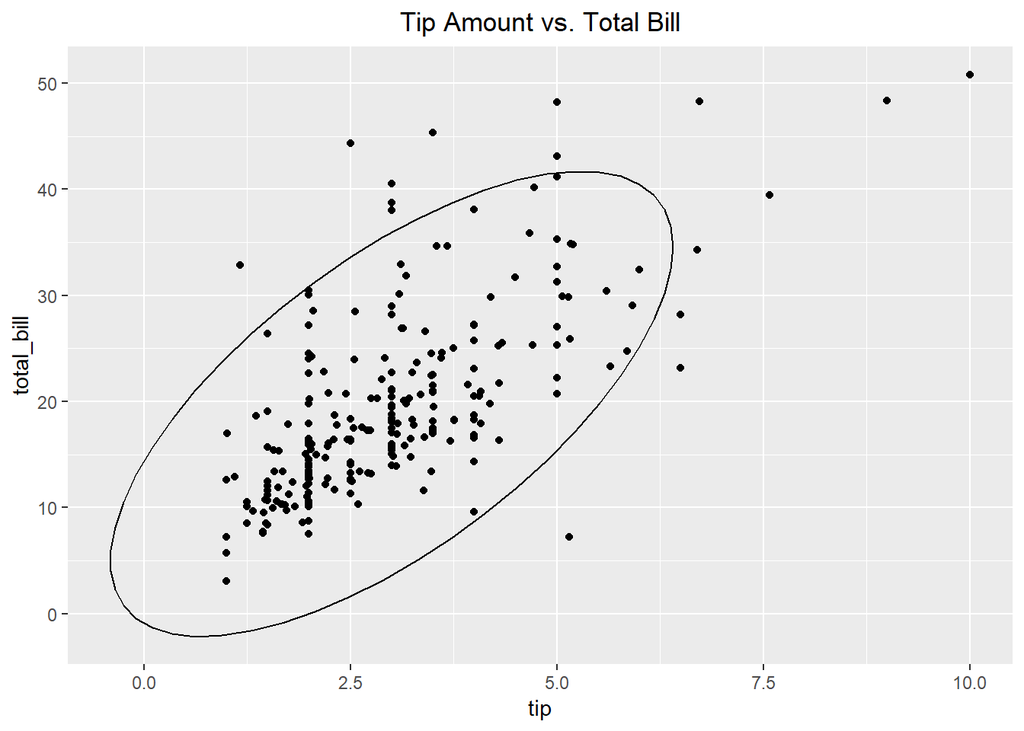

```r
ggplot(tips, aes(x=tip, y=total_bill)) + geom_point() + stat_ellipse(type="norm") + ggtitle("Tip Amount vs. Total Bill") + theme(plot.title=element_text(hjust=0.5))
```

## 6.

```r
tips$tiprate <- tips$tip / tips$total_bill
head(tips, 10) # to show new column
```

```
##    total_bill  tip    sex smoker day   time size    tiprate
## 1       16.99 1.01 Female     No Sun Dinner    2 0.05944673
## 2       10.34 1.66   Male     No Sun Dinner    3 0.16054159
## 3       21.01 3.50   Male     No Sun Dinner    3 0.16658734
## 4       23.68 3.31   Male     No Sun Dinner    2 0.13978041
## 5       24.59 3.61 Female     No Sun Dinner    4 0.14680765
## 6       25.29 4.71   Male     No Sun Dinner    4 0.18623962
## 7        8.77 2.00   Male     No Sun Dinner    2 0.22805017
## 8       26.88 3.12   Male     No Sun Dinner    4 0.11607143
## 9       15.04 1.96   Male     No Sun Dinner    2 0.13031915
## 10      14.78 3.23   Male     No Sun Dinner    2 0.21853857
```

```r
avgTip <- mean(tips$tiprate)
avgTip # average tip rate is approximately 16%
```

```
## [1] 0.1608026
```

## 7.

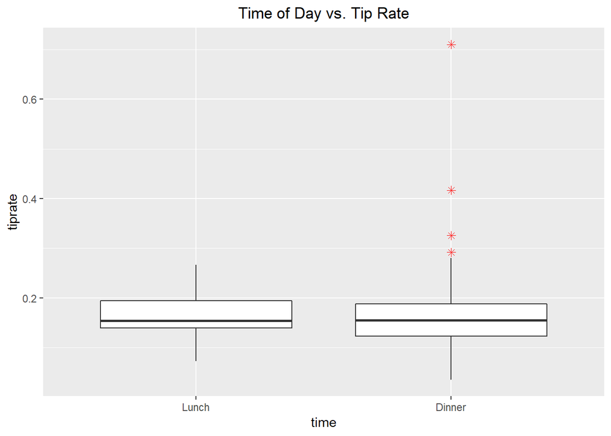

```r
tips$time <- factor(tips$time, levels = c("Lunch", "Dinner"))
temp <- tips[order(tips$time),] # to hold new ordering
p <- ggplot(temp, aes(x=time, y=tiprate)) + geom_boxplot(outlier.color="red", outlier.shape=8, outlier.size=2)
p <- p + ggtitle("Time of Day vs. Tip Rate") + theme(plot.title=element_text(hjust=0.5))
p
```

## 8

The relation between tip and total bill here is easily represented by the tiprate column, however I will use both for the scatterplots. From here I will try and find meaning between smoking and gender of person who pays to the tip rate. I used the ggpubr library, which I found useful during an internship I had this past summer. It is helpful for arranging graphs.

```r
library("ggpubr")
```

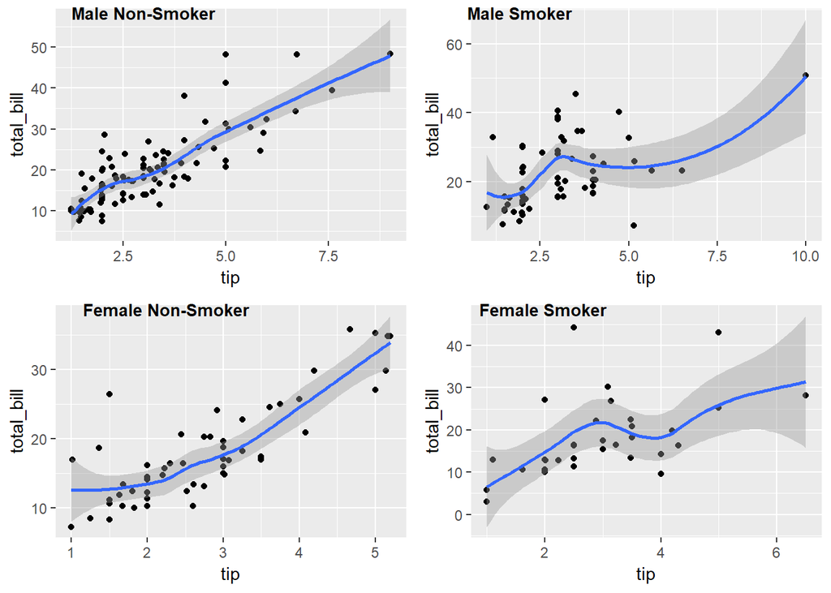

```r
# I had to make some dataframes so these scatterplots could be created easier

female <- tips[(tips$sex == 'Female'),]
f_noSmoke <- female[(female$smoker == 'No'),]
f_yesSmoke <- female[(female$smoker == 'Yes'),]
male <- tips[(tips$sex == 'Male'),]
m_noSmoke <- male[(male$smoker == "No"),]
m_yesSmoke <- male[(male$smoker == "Yes"),]

# Now making scatterplots to then turn into a grid

f_no <- ggplot(f_noSmoke, aes(x=tip, y=total_bill)) + geom_point() + geom_smooth()
f_yes <- ggplot(f_yesSmoke, aes(x=tip, y=total_bill)) + geom_point() + geom_smooth()
m_no <- ggplot(m_noSmoke, aes(x=tip, y=total_bill)) + geom_point() + geom_smooth()
m_yes <- ggplot(m_yesSmoke, aes(x=tip, y=total_bill)) + geom_point() + geom_smooth()

# Using ggarrange to organize into grid

plots <- ggarrange(m_no, m_yes, f_no, f_yes, labels=c("Male Non-Smoker", "Male Smoker", "Female Non-Smoker", "Female Smoker"), font.label=list(size = 10, color="black"), ncol=2,nrow=2)
plots
```

From this result, here are my interpretations: I think that females, when paying, tend to have lower overall bills and therefore lower tips. However, it seems that they have a lower tip rate. A flatter regression line will show that the tip rate is higher, and both male smokers and non-smokers exhibit a flatter lines than their female counterparts, which implies a higher tip rate. When looking at smoking specifically, it appears that the smokers tend to tip better than non-smokers, based on the shape of the regression lines. Overall, there is some interesting information to draw from these graphs, which is easy to compare when they are side-by-side.

## 9.

I decided to use a bar plot to describe and analyze this data.

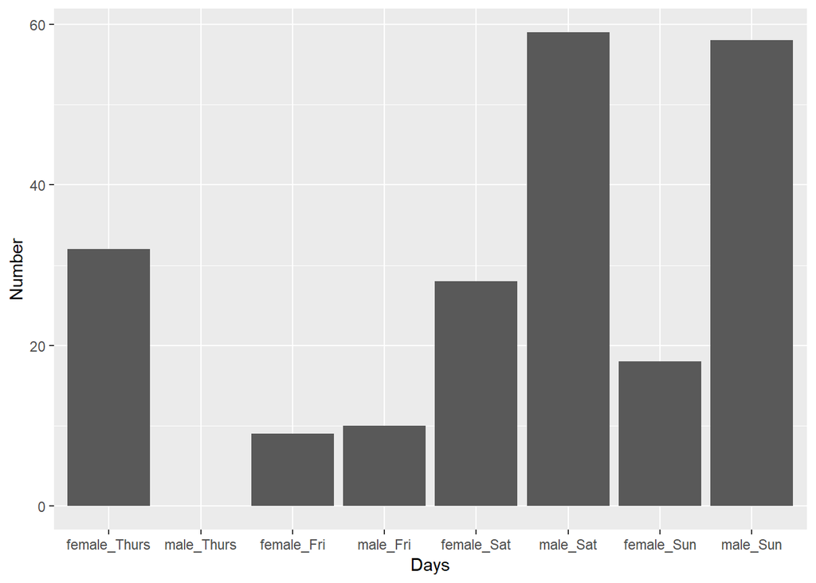

```r
# First creating a vector of numerical values so the bar plot has some meaning (can reuse male, female dataframes from earlier)

fT <- female[(female$day == "Thur"),]
fF <- female[(female$day == "Fri"),]
fSa <- female[(female$day == "Sat"),]
fSu <- female[(female$day == "Sun"),]
mT <- male[(male$day == "Thurs"),]
mF <- male[(male$day == "Fri"),]
mSa <- male[(male$day == "Sat"),]
mSu <- male[(male$day == "Sun"),]

yvals <- c(nrow(fT),nrow(mT),nrow(fF),nrow(mF),nrow(fSa),nrow(mSa),nrow(fSu),nrow(mSu))
xvals <- c("female_Thurs","male_Thurs","female_Fri","male_Fri","female_Sat","male_Sat","female_Sun","male_Sun")
toPlot <- data.frame("Days" = xvals, "Number" = yvals)
positions <- c("female_Thurs","male_Thurs","female_Fri","male_Fri","female_Sat","male_Sat","female_Sun","male_Sun")
ggplot(toPlot, aes(Days, Number)) + geom_bar(stat="identity") + scale_x_discrete(limits=positions)
```